# COMPSCIX 415.2 Homework 7

Aparna Vaidya

3/13/2019

```r
library(tidyverse)
library(broom)
```

### Exercise 1

**Load the train.csv dataset into R. How many observations and columns are there?**

There are 1,460 observations and 81 columns.

```r
train <- read.csv("/Users/aparnavaidya/Downloads/UCB-Intro To Data Science/compscix-415-2-assignments/Lab7/train.csv")

glimpse(train)
```

```
## Observations: 1,460
## Variables: 81
## $ Id            <int> 1, 2, 3, 4, 5, 6, 7, 8, 9, 10, 11, 12, 13, 14, 15,…
## $ MSSubClass    <int> 60, 20, 60, 70, 60, 50, 20, 60, 50, 190, 20, 60, 2…
## $ MSZoning      <fct> RL, RL, RL, RL, RL, RL, RL, RL, RM, RL, RL, RL, RL…
## $ LotFrontage   <int> 65, 80, 68, 60, 84, 85, 75, NA, 51, 50, 70, 85, NA…
## $ LotArea       <int> 8450, 9600, 11250, 9550, 14260, 14115, 10084, 1038…
## $ Street        <fct> Pave, Pave, Pave, Pave, Pave, Pave, Pave, Pave, Pa…
## $ Alley         <fct> NA, NA, NA, NA, NA, NA, NA, NA, NA, NA, NA, NA, NA…
## $ LotShape      <fct> Reg, Reg, IR1, IR1, IR1, IR1, Reg, IR1, Reg, Reg, …
## $ LandContour   <fct> Lvl, Lvl, Lvl, Lvl, Lvl, Lvl, Lvl, Lvl, Lvl, Lvl, …
## $ Utilities     <fct> AllPub, AllPub, AllPub, AllPub, AllPub, AllPub, Al…
## $ LotConfig     <fct> Inside, FR2, Inside, Corner, FR2, Inside, Inside, …
## $ LandSlope     <fct> Gtl, Gtl, Gtl, Gtl, Gtl, Gtl, Gtl, Gtl, Gtl, Gtl, …
## $ Neighborhood  <fct> CollgCr, Veenker, CollgCr, Crawfor, NoRidge, Mitch…
```

[output cut: 68 more lines]

### Exercise 2

**Normally at this point you would spend a few days on EDA, but for this homework we will do some very basic EDA and get right to fitting some linear regression models.**

**Our target will be SalePrice.**

**Visualize the distribution of SalePrice.**

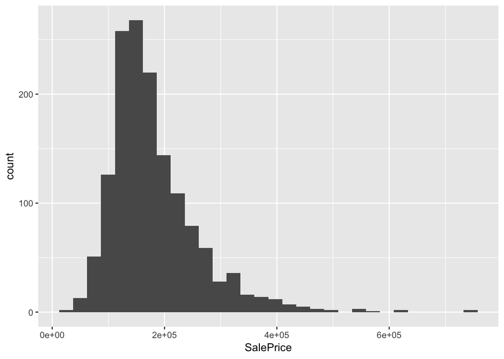

```r
ggplot(data = train, mapping = aes(x = SalePrice)) + geom_histogram()
```

**Visualize the covariation between SalePrice and Neighborhood.**

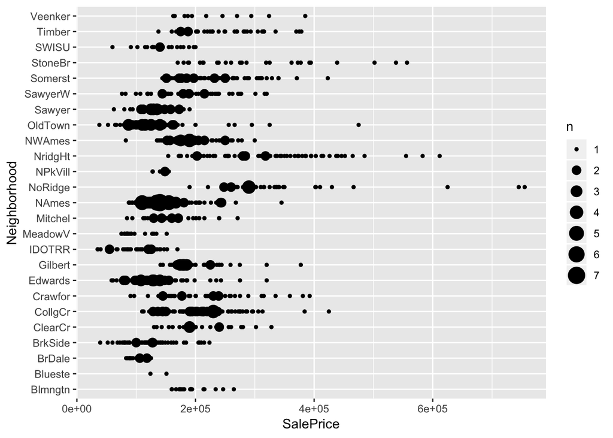

```r
ggplot(data = train) +
  geom_count(mapping = aes(x = SalePrice, y = Neighborhood))
```

**Visualize the covariation between SalePrice and OverallQual.**

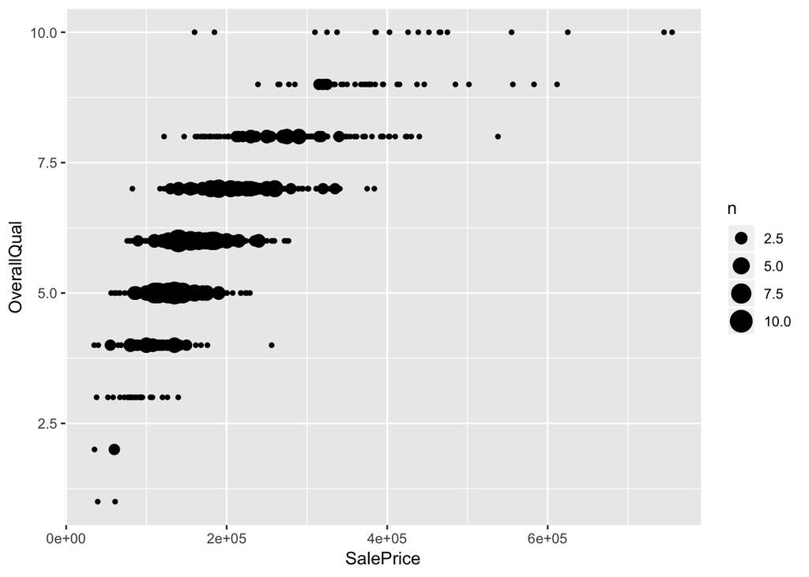

```r
ggplot(data = train) +
  geom_count(mapping = aes(x = SalePrice, y = OverallQual))
```

### Exercise 3

**Our target is called SalePrice. First, we can fit a simple regression model consisting of only the intercept (the average of SalePrice). Fit the model and then use the broom package to**

**take a look at the coefficient,** **compare the coefficient to the average value of SalePrice, and** **take a look at the R-squared.**

```r
(sale_lm <- lm(formula = SalePrice ~ 1, data = train))
```

```
##
## Call:
## lm(formula = SalePrice ~ 1, data = train)
##
## Coefficients:
## (Intercept)
##      180921
```

```r
glance(sale_lm)
```

```
## # A tibble: 1 x 11
##   r.squared adj.r.squared  sigma statistic p.value    df  logLik    AIC
##       <dbl>         <dbl>  <dbl>     <dbl>   <dbl> <int>   <dbl>  <dbl>
## 1         0             0 79443.        NA      NA     1 -18544. 37092.
## # … with 3 more variables: BIC <dbl>, deviance <dbl>, df.residual <int>
```

```r
mean(train$SalePrice)
```

```
## [1] 180921.2
```

### Exercise 4

**Now fit a linear regression model using GrLivArea, OverallQual, and Neighborhood as the features. Don’t forget to look at data_description.txt to understand what these variables mean. Ask yourself these questions before fitting the model:**

**What kind of relationship will these features have with our target?**

These features will have a positive linear relationship with the target.

**Can the relationship be estimated linearly?**

Yes.

**Are these good features, given the problem we are trying to solve?**

Mostly yes. Because they seem to be linear, indeoendent and uncorrelated.

**After fitting the model, output the coefficients and the R-squared using the broom package.**

```r
(sale_lm <- lm(formula = SalePrice ~ GrLivArea + OverallQual + Neighborhood, data = train))
```

```
##
## Call:
## lm(formula = SalePrice ~ GrLivArea + OverallQual + Neighborhood,
##     data = train)
##
## Coefficients:
##         (Intercept)            GrLivArea          OverallQual
##           -34829.24                55.56             20951.42
## NeighborhoodBlueste   NeighborhoodBrDale  NeighborhoodBrkSide
##           -30752.88            -43358.88            -13025.45
## NeighborhoodClearCr  NeighborhoodCollgCr  NeighborhoodCrawfor
##            24575.64             11414.31             14444.25
## NeighborhoodEdwards  NeighborhoodGilbert   NeighborhoodIDOTRR
##           -17842.95              -892.88            -28178.99
## NeighborhoodMeadowV  NeighborhoodMitchel    NeighborhoodNAmes
##           -19099.02              2030.61             -4430.10
## NeighborhoodNoRidge  NeighborhoodNPkVill  NeighborhoodNridgHt
##            64642.99            -17807.18             71587.84
##  NeighborhoodNWAmes  NeighborhoodOldTown   NeighborhoodSawyer
##            -4720.66            -32080.88             -1219.38
## NeighborhoodSawyerW  NeighborhoodSomerst  NeighborhoodStoneBr
##              303.10             17766.96             69954.47
##   NeighborhoodSWISU   NeighborhoodTimber  NeighborhoodVeenker
##           -36640.15             29905.81             47106.89
```

```r
glance(sale_lm)
```

```
## # A tibble: 1 x 11
##   r.squared adj.r.squared  sigma statistic p.value    df  logLik    AIC
##       <dbl>         <dbl>  <dbl>     <dbl>   <dbl> <int>   <dbl>  <dbl>
## 1     0.787         0.783 37009.      203.       0    27 -17416. 34887.
## # … with 3 more variables: BIC <dbl>, deviance <dbl>, df.residual <int>
```

Answer these questions:

**How would you interpret the coefficients on GrLivArea and OverallQual?**

For every one unit increase in GrLiveArea, SalePrice would increase by $55.56. If GrLiveArea = 0, Sale Price would be -34829.24

For every one unit increase in OverallQual, SalePrice would increase by $20951.42. If OverallQual = 0, Sale Price would be -34829.24

**How would you interpret the coefficient on NeighborhoodBrkSide?**

Keeping everything else constant, house prices in NeighborhoodBrkSide will be $13025.45 less than house prices in Bloomington Heights.

**Are the features significant?**

Features are significant since they have non-zero values.

**Are the features practically significant?**

Features are practically significant since prices can be higher or lower than the base neighborhood price.

**Is the model a good fit?**

Model is a good fit since it has a higher R squared value.

### Exercise 5 (OPTIONAL - won’t be graded)

**Feel free to play around with linear regression. Add some other features and see how the model results change.**

```r
(sale_lm <- lm(formula = SalePrice ~ LotConfig + Utilities, data = train))
```

```
##
## Call:
## lm(formula = SalePrice ~ LotConfig + Utilities, data = train)
##
## Coefficients:
##      (Intercept)  LotConfigCulDSac      LotConfigFR2      LotConfigFR3
##           181623             43160             -3689             26852
##  LotConfigInside   UtilitiesNoSeWa
##            -4685            -87283
```

```r
glance(sale_lm)
```

```
## # A tibble: 1 x 11
##   r.squared adj.r.squared  sigma statistic p.value    df  logLik    AIC
##       <dbl>         <dbl>  <dbl>     <dbl>   <dbl> <int>   <dbl>  <dbl>
## 1    0.0218        0.0185 78705.      6.49 5.58e-6     6 -18528. 37070.
## # … with 3 more variables: BIC <dbl>, deviance <dbl>, df.residual <int>
```

### Exercise 6

**One downside of the linear model is that it is sensitive to unusual values because the distance incorporates a squared term. Fit a linear model to the simulated data below (use y as the target and x as the feature), and look at the resulting coefficients and R-squared. Rerun it about 5-6 times to generate different simulated datasets. What do you notice about the model’s coefficient on x and the R-squared values?**

```r
sim1a <- tibble(
  x = rep(1:10, each = 3),
  y = x * 1.5 + 6 + rt(length(x), df = 2)
)

(sim1a_lm <- lm(formula = y ~ x, data = sim1a))
```

```
##
## Call:
## lm(formula = y ~ x, data = sim1a)
##
## Coefficients:
## (Intercept)            x
##        5.95         1.63
```

```r
glance(sim1a_lm)
```

```
## # A tibble: 1 x 11
##   r.squared adj.r.squared sigma statistic  p.value    df logLik   AIC   BIC
##       <dbl>         <dbl> <dbl>     <dbl>    <dbl> <int>  <dbl> <dbl> <dbl>
## 1     0.869         0.864  1.88      186. 6.97e-14     2  -60.5  127.  131.
## # … with 2 more variables: deviance <dbl>, df.residual <int>
```